# What’s Will Watching On YouTube?

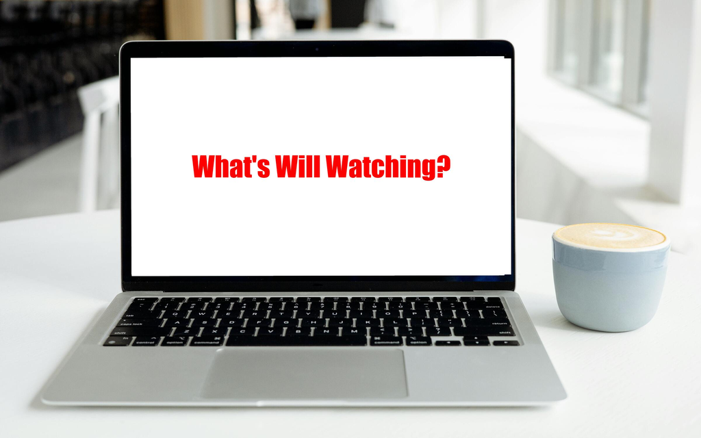

Have you ever found yourself wondering what THE Will Hopkins has been watching on YouTube recently? It’s your lucky day as this is a statistical summary of my recent YouTube activity.

## A general summary of recent video consumption.

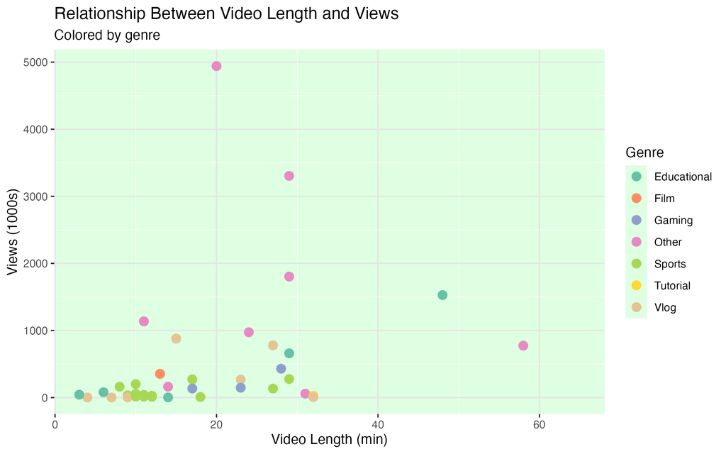

A scatter plot showing the length and video views of different videos watched recently coloured by the genre they belong to.

Only videos that were added to the collection in the recent month are shown due to the fact that video views were not included in the original set of questions in Project 2. Shorter videos are clearly more common also interestingly the number of views per video is quite low suggesting more niche content consumption.

## A change in viewing habits?

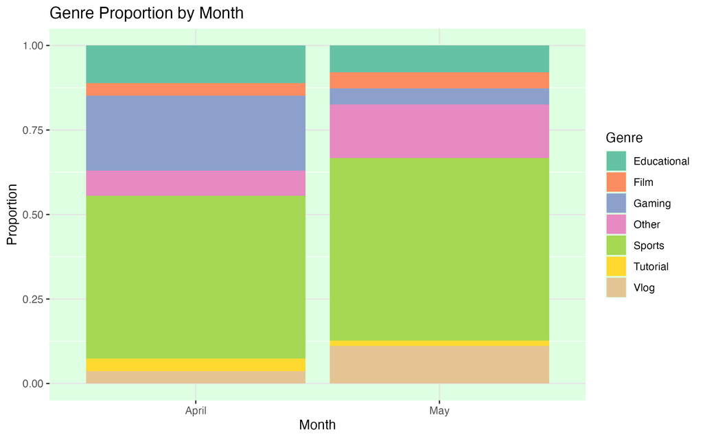

It seems clear that as the NBA season has come to an end and the playoffs have begun my intake of sports related YouTube videos has remained the largest. Vlogs have become more common while gaming has a smaller share of videos. The most interesting increase is in the “Other” category displaying that when I made this question for Project 2 it encapsulated my viewing habits better.

## An easy method for clicks?

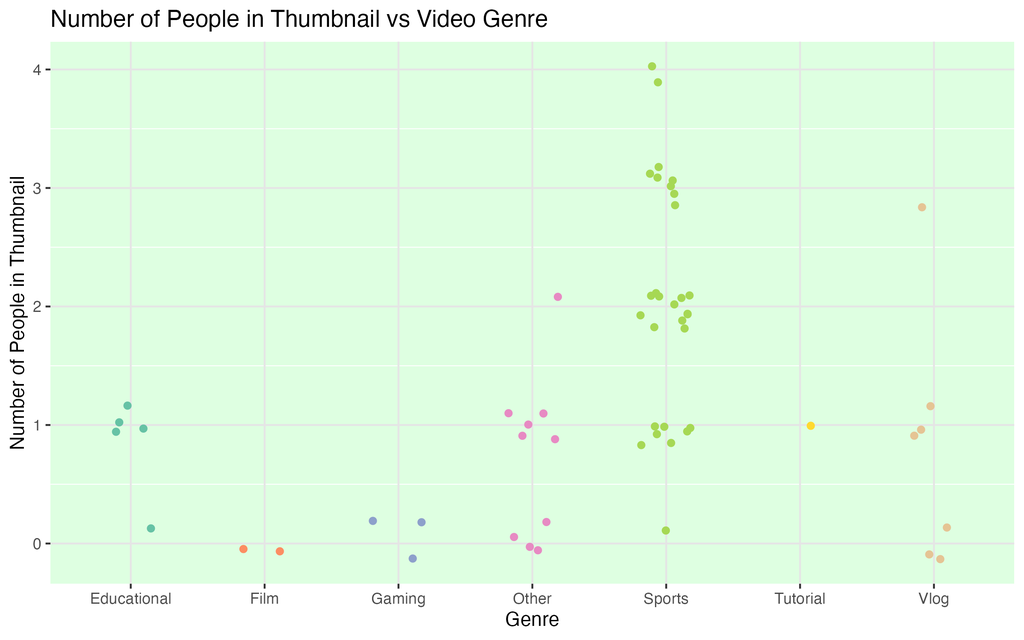

## Conclusion

It is of no surprise that I have not completely changed the variety of videos I watch in the span of 1 month too drastically however these graphs provide useful insight into that unchanging variety. Short form (20 minutes or less) sports content is a much more dominant force than expected signally that it may be time to get some more hobbies…

[figure not shown]